# 218013

*N* removed NAs: 2

*N* removed typo: 1

*N* removed <18: 18

*N* total clean: 129

| Group | *N* | *M*<sub>age</sub> | *M*<sub>rating</sub> |
| --- | --- | --- | --- |
| Control | 63 | 20.52 | 6.05 |
| Experim | 66 | 20.80 | 5.48 |

**Main analysis results**

*t*(127) = 3.45, *p* < .001

[interactive chart not shown]

[figure not shown]

[interactive chart not shown]

# 218013

Red Effect, Revised - Analysing Data, Spring 2020

# Methods

## Participants

**Table 1:** Participant descriptives, *grouped by condition*

| Condition | **N** | **%** | **Mean<sub>Age</sub>** | **SD<sub>Age</sub>** |
| --- | --- | --- | --- | --- |
| control | 62 | 48.82 | 20.52 | 1.90 |
| experimental | 65 | 51.18 | 20.83 | 2.26 |

150 female participants originally took part in the study (mean age: 20.09, SD: 2.52, range 13 - 27). Data from participants younger than 18 years (n=18) and those for whom age data is unavailable (n=3) have been removed, as it would be unethical to use data from minors. Data from participants assigned identical ID codes (n=2) was also removed. Thus, data from 127 participants was included in the final analysis (mean age: 20.68, SD: 2.09, range 18 - 27).

## Design

This study aims to investigate whether the colour *red* makes men appear more attractive to women. Participants are shown a black-and-white image of a man on either a red (n=65) or white (n=62) background for 5 seconds. They are then asked to rate the following items on a 9-point scale (1- *not at all attractive*, 9- *extremely attractive*):

1. How attractive do you think this person is?
2. How pleasant is this person to look at?
3. If I were to meet the person in this picture face-to-face, I would think he is attractive.

Hereby, ‘attractiveness’ is measured as a rating; 3 scores will be obtained from each participant, and used to assess whether the IV factors (red/white) have an impact on perceived attractiveness.

This study is a replication of Experiment 1 from original research by Elliot, Niesta Kayser, and Greitemeyer, (2010). We will be using the same colour and size parameters for the backgrounds in our study (red = LCh(49.6, 58.8, 30.4), white = ‘the absence of additional colour’). The same 4-inch x 6-inch photo will be centred on an 8.5-inch x 11-inch page.

**Women who view a black-and-white image of a man on a red background will rate him as more attractive than women who view the same image on a white background, as assessed using a *t*-test at .05 significance.**

# Results

## Summary

**Table 2:** Mean and Standard Deviation of participant responses for each question, in each condition

| Condition | Question 1 Mean | Question 1 SD | Question 2 Mean | Question 2 SD | Question 3 Mean | Question 3 SD | Overall Mean | Overall SD |
| --- | --- | --- | --- | --- | --- | --- | --- | --- |
| control | 6.03 | 1.48 | 5.87 | 1.60 | 6.21 | 1.34 | 6.04 | 1.04 |
| experimental | 5.63 | 1.53 | 5.40 | 1.44 | 5.43 | 1.44 | 5.49 | 0.83 |

A composite index of perceived attractiveness was constructed by averaging the three scores obtained from each participant. Overall, participants in the experimental (red) condition rated the man as less attractive (mean: 5.49, SD: 0.83) than participants in the control (white) condition (mean: 6.04, SD: 1.04). Mean attractiveness rating is greater in the control condition for each of the three measures, although greater variance occured in responses to questions 1 and 3 in the experimental condition.

## Plots

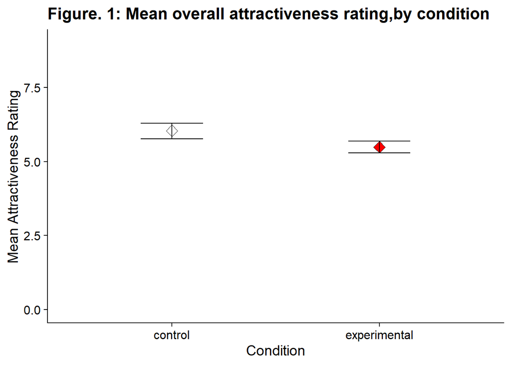

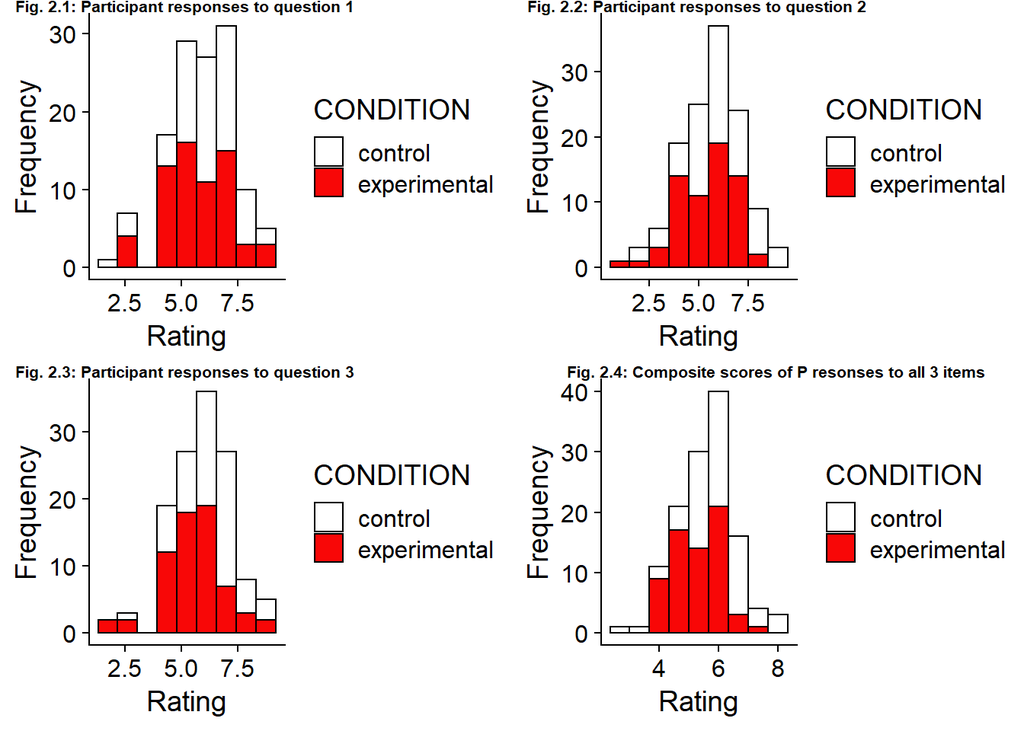

On average, participants in the *white* condition rated the image as more attractive, than participants in the *red* condition.

## Statistics

This experiment aimed to test whether red enhances females’ attraction to men. Our results appear to imply that he will be rated more attractively when presented with the colour white (mean: 6.04 ) than the colour red (mean: 5.49), contradicting our hypothesis.

We analysed these results using an independent measures t-test, which showed that the difference we found was significant. (*M*<sub>diff</sub> = 0.55, 95% CI [0.22, 0.88], *t*(125) = 3.30, *p* = .001)

The results of the *t*-test show that the results are statistically significant; the probability of these results occuring by chance is less than our chosen significance level (5%), indicating that women find men more attractive when their image is presented on a white background, rather than a red background.

# Discussion

## Implications

We investigated the effect of colour on female ratings of male attractiveness using an independent measures design, in which 127 female participants rated how attractive they found a male, on 3 9-point Likert scales. Our results showed that women rate men significantly more attractively when viewed on a white background, than when viewed on a red background. These results appear to directly contradict previous research into the *red-effect*, which suggests *red* may increase women’s physical attraction to men (Elliot *et al.*, 2010).

This study was a replication of the first of 7 experiments conducted by Elliot *et al.* (2010), who believed *red* may enhance women’s attraction to men due to its association with high-status. Their results showed that participants in the *red* condition rated the man as significantly more attractive than those in the *white* condition; the complete opposite results to ours. Therefore, it is possible that our results could serve as evidence to challenge *Elliot et al.*’s findings, suggesting no effect of red on attractiveness.

## Ecological limitations

Interestingly, our results directly contradict Elliot *et al* (2010), implying that women actually find men more attractive in the absence of colour, than in conjunction with *red*. The use of highly standardized procedures (i.e. all participants viewed the same-sized image of the same man, on the same-sized background for the same amount of time) and large sample size support the internal validity of this study. However, the extent to which these findings are generalizable to real-life scenarios is questionable.

In reality, many extraneous influences, such as personal preference for specific facial and body types, previous encounters, verbal interactions and contextual knowledge about the individual, have an impact on how attractive one may find another person. It’s possible that a greater number of participants in the control condition than the experimental condition tend to find men of a similar appearance to the one in the photograph attractive.

Additionally, in real-life, it’s unlikely that a woman would view a mostly colourless man on a red/white background; the colour association is likely to come from, say, the clothing he is wearing, or a bag which he is carrying; items much more closely associated with the individual’s character and actual appearance than the background in front of which he stands. Therefore, it is difficult to ascertain whether colour (or lack thereof) actually has an impact on attractiveness in real life; it would be interesting to conduct similar research using real people instead of photographs.

## Sampling

A strength of our study was the large sample size (n=127); the original study’s sample was much smaller (n=21), so it is possible that our sample was more representative of the general population, and therefore, our results are more generalizable to wider populations. It is therefore possible that the *red-effect* does not exist, and that *white* may even enhance attraction in the general population.

Additionally, it’s possible that in the smaller sample, a greater proportion of participants in any one condition (in Elliot *et al.*’s case, the *red* condition) may have a personal preference for specific characteristics exhibited by the man in the photo - i.e. hair colour or posture - which could’ve influenced their ratings of attractiveness, therefore compromising the validity of their results.

It is also possible that the *red effect* is more selective in its effects than Elliot *et al* described. Schwarz & Singer (2013) showed that red enhances men’s attraction to young, but not older, women, implying that red may enhance attraction to members of the opposite sex when attraction is already present, but not when one is not already attracted to the other person. Other research has shown that red enhances men’s attraction to feminine female faces, but not masculine female faces, further suggesting that red may enhance only pre-existing attraction (Wen, Zuo, Wu, Sun and Liu, 2014). This suggests that while *red* may have enhanced pre-existing attraction within the experimental condition of Elliot *et al.*’s study, other extraneous factors may be more important, and even precede the influence of *red*. In our larger sample, it is possible that a smaller proportion of experimental participants were naturally attracted to the man in the photo, therefore reducing the *red-effect*; further research is necessary to support this hypothesis.

It is important to note that the cited studies were conducted on men, so it’s possible that the results are not generalisable to female populations. It’s possible that sex differences exist in terms of factors which influences perceptions of attractiveness; for instance, based on participant’s ratings of 3 black-and-white photographs of members of the opposite sex alongside job and salary descriptions implying socioeconomic status (SES), Townsend and Levy (1990) found that women place more emphasis than men on their partners’ SES in sexual relationships than men do.

## Reliability

A similar replication attempt by Hesslinger, Goldbach, and Carbon (2015) (n=72) found no significant impact of *red* on female attraction to the male image (*red*: M=5.71, SD=1.7; *white*: M=5.39, SD=1.53). When considering these results alongside ours (and those of Elliot *et al.* (2010)), it is clear that this experimental method produces extremely variable results when replicated; especially with larger samples. Therefore, I believe that this experiment is not the most reliable method of assessing the *red-effect*.

## Status??

In a second experiment, Hesslinger *et al.* (2015) *did* find a link between apparel style and attractiveness, wherein attractiveness ratings were higher for men wearing formal apparel, compared with casual. This brings my attention back to the logic behind Elliot *et al.* (2010)’s research; that red may enhance attraction due to its association with high-status. Formal apparel is likely associated with higher-status professions/social status than casual apparel, implying that the actual underlying influence on attraction may be the woman’s perception of the man’s status.

Evidence to suggest this association between *red* and *status* comes from observations of the animal kingdom; for intance, loss/gain of Alpha status has been associated with a respective decrease/increase in reddening of skin on face and genitalia in Male Mandrills; colouration of blue skin was unaffected, suggesting a biological link specifically between *red* and status (Setchell & Dixson, 2001). Human research has also demonstrated an this association in both the UK and China (Wu, Lu, van Dijk, Li & Schnall, 2018); they showed that high-status car logos are more easily associated with *red* than *white*. This implies that the preference for *red* in Elliot *et al.* (2010) may have actually indicated an association between red and high-status; their results, therefore, may imply the influence of status on attraction, rather than the influence of *red* itself. The influence of perception of high-status on attraction may have been reduced when the study was conducted on a larger sample in my own replication, and that of Hesslinger *et al.* (2015).

## Conclusion

My findings imply that women actually find men more attractive in the absence of colour entirely, than when presented alongside the colour red. In light of my findings, and those of other, similar replications, I think it is unlikely that the *red-effect* itself is real; instead, I think other, extraneous influences may have a greater effect, and that it is possible that *red* interacts with these other influences in some way. Whilst the results of my experiment imply that women actually find men more attractive when viewed alongside *white* than *red*, I do not believe that we have gathered sufficient evidence to suggest either that white does, or that red does not, make men more attractive to women, due to design issues surrounding ecological validity and methodological reliability.

Whilst there is some evidence to suggest an effect of red on attraction, the evidence is weak at best, and effects are often only *just* significant. Future research should consider the effects of other markers of high-status, such as apparel style, posture, facial expression and even personal background, in comparison and alongside the colour *red*. This will help us to isolate the exact impact which *red* may have on attraction, guiding us towards a more valid measure of any specific *red-effect*. It would also be interesting to conduct experiments similar to this one (& that of Elliot *et al.* (2010)) using different colours for the background - i.e. blue and green - using multiple models of different facial/body types, to see if they have an effect on perceptions of attraction; although, the variable results demonstrated by this study and other replications (Hesslinger *et al.* (2015)) challenge the reliability of this experimental method.

# References

Elliot, A., Niesta Kayser, D., & Greitemeyer, T. (2010, August). Red, rank, and romance in women viewing men. *Journal of Experimental Psychology,* 139(3), 399-417. DOI:10.1037/a0019689

Hesslinger, V.M., Goldbach, L., & Carbon, C.C. (2015). Men in red: A reexamination of the red-attractiveness effect. *Psychonomic Bulletin & Review,* 22(4), 1142–1148. DOI:10.3758/s13423-015-0866-8

*** WORD LIMIT REACHED ***

Setchell, J. M., & Dixson, A. F. (2001). Changes in the Secondary Sexual Adornments of Male Mandrills (Mandrillus sphinx) Are Associated with Gain and Loss of Alpha Status. *Hormones and Behavior,* 39(3), 177–184. DOI:10.1006/hbeh.2000.1628

Schwarz, S., & Singer, M. (2013). Romantic red revisited: Red enhances men’s attraction to young, but not menopausal women. *Journal of Experimental Social Psychology,* 49(1), 161–164. DOI:10.1016/j.jesp.2012.08.004

Townsend, J. M., & Levy, G. D. (1990). Effects of potential partners’ physical attractiveness and socioeconomic status on sexuality and partner selection. *Archives of Sexual Behavior,* 19(2), 149–164. DOI:10.1007/BF01542229

Wen, F., Zuo, B., Wu, Y., Sun, S., & Liu, K. (2014). Red is Romantic, but Only for Feminine Females: Sexual Dimorphism Moderates Red Effect on Sexual Attraction. *Evolutionary Psychology,* 12(4). DOI:10.1177/147470491401200404

Wu, Y., Lu, J., van Dijk, E., Li, H., & Schnall, S. (2018). The Color Red Is Implicitly Associated With Social Status in the United Kingdom and China. *Frontiers in Psychology,* 9. DOI:10.3389/fpsyg.2018.01902